# IE 451 Applied Data Analysis Homework 1

Author

Emre Anil Polat, Your 22002225

Published

October 19, 2024

# 1 1- Start By Exploring Data

```r
data <- read.csv("used-cars.csv")

head(data)
```

```
  Id                                         Model Price Age_08_04 Mfg_Month
1  1 TOYOTA Corolla 2.0 D4D HATCHB TERRA 2/3-Doors 13500        23        10
2  2 TOYOTA Corolla 2.0 D4D HATCHB TERRA 2/3-Doors 13750        23        10
3  3 TOYOTA Corolla 2.0 D4D HATCHB TERRA 2/3-Doors 13950        24         9
4  4 TOYOTA Corolla 2.0 D4D HATCHB TERRA 2/3-Doors 14950        26         7
5  5   TOYOTA Corolla 2.0 D4D HATCHB SOL 2/3-Doors 13750        30         3
6  6   TOYOTA Corolla 2.0 D4D HATCHB SOL 2/3-Doors 12950        32         1
  Mfg_Year    KM Fuel_Type HP Met_Color  Color Automatic   CC Doors Cylinders
1     2002 46986    Diesel 90         1   Blue         0 2000     3         4
2     2002 72937    Diesel 90         1 Silver         0 2000     3         4
3     2002 41711    Diesel 90         1   Blue         0 2000     3         4
4     2002 48000    Diesel 90         0  Black         0 2000     3         4
5     2002 38500    Diesel 90         0  Black         0 2000     3         4
6     2002 61000    Diesel 90         0  White         0 2000     3         4
  Gears Quarterly_Tax Weight Mfr_Guarantee BOVAG_Guarantee Guarantee_Period ABS
```

[output cut: 27 more lines]

```r
summary(data)
```

```
       Id            Model               Price         Age_08_04
 Min.   :   1.0   Length:1436        Min.   : 4350   Min.   : 1.00
 1st Qu.: 361.8   Class :character   1st Qu.: 8450   1st Qu.:44.00
 Median : 721.5   Mode  :character   Median : 9900   Median :61.00
 Mean   : 721.6                      Mean   :10731   Mean   :55.95
 3rd Qu.:1081.2                      3rd Qu.:11950   3rd Qu.:70.00
 Max.   :1442.0                      Max.   :32500   Max.   :80.00
   Mfg_Month         Mfg_Year          KM          Fuel_Type
 Min.   : 1.000   Min.   :1998   Min.   :     1   Length:1436
 1st Qu.: 3.000   1st Qu.:1998   1st Qu.: 43000   Class :character
 Median : 5.000   Median :1999   Median : 63390   Mode  :character
 Mean   : 5.549   Mean   :2000   Mean   : 68533
 3rd Qu.: 8.000   3rd Qu.:2001   3rd Qu.: 87021
 Max.   :12.000   Max.   :2004   Max.   :243000
       HP          Met_Color         Color             Automatic
 Min.   : 69.0   Min.   :0.0000   Length:1436        Min.   :0.00000
 1st Qu.: 90.0   1st Qu.:0.0000   Class :character   1st Qu.:0.00000
 Median :110.0   Median :1.0000   Mode  :character   Median :0.00000
 Mean   :101.5   Mean   :0.6748                      Mean   :0.05571
 3rd Qu.:110.0   3rd Qu.:1.0000                      3rd Qu.:0.00000
 Max.   :192.0   Max.   :1.0000                      Max.   :1.00000
       CC            Doors         Cylinders     Gears       Quarterly_Tax
 Min.   : 1300   Min.   :2.000   Min.   :4   Min.   :3.000   Min.   : 19.00
 1st Qu.: 1400   1st Qu.:3.000   1st Qu.:4   1st Qu.:5.000   1st Qu.: 69.00
 Median : 1600   Median :4.000   Median :4   Median :5.000   Median : 85.00
 Mean   : 1577   Mean   :4.033   Mean   :4   Mean   :5.026   Mean   : 87.12
 3rd Qu.: 1600   3rd Qu.:5.000   3rd Qu.:4   3rd Qu.:5.000   3rd Qu.: 85.00
 Max.   :16000   Max.   :5.000   Max.   :4   Max.   :6.000   Max.   :283.00
     Weight     Mfr_Guarantee    BOVAG_Guarantee  Guarantee_Period
 Min.   :1000   Min.   :0.0000   Min.   :0.0000   Min.   : 3.000
 1st Qu.:1040   1st Qu.:0.0000   1st Qu.:1.0000   1st Qu.: 3.000
 Median :1070   Median :0.0000   Median :1.0000   Median : 3.000
 Mean   :1072   Mean   :0.4095   Mean   :0.8955   Mean   : 3.815
 3rd Qu.:1085   3rd Qu.:1.0000   3rd Qu.:1.0000   3rd Qu.: 3.000
 Max.   :1615   Max.   :1.0000   Max.   :1.0000   Max.   :36.000
      ABS            Airbag_1         Airbag_2          Airco
 Min.   :0.0000   Min.   :0.0000   Min.   :0.0000   Min.   :0.0000
 1st Qu.:1.0000   1st Qu.:1.0000   1st Qu.:0.0000   1st Qu.:0.0000
 Median :1.0000   Median :1.0000   Median :1.0000   Median :1.0000
 Mean   :0.8134   Mean   :0.9708   Mean   :0.7228   Mean   :0.5084
```

[output cut: 15 more lines]

```
 Max.   :1.000   Max.   :1.0000   Max.   :1.0000   Max.   :1.000
  Sport_Model     Backseat_Divider  Metallic_Rim    Radio_cassette
 Min.   :0.0000   Min.   :0.0000   Min.   :0.0000   Min.   :0.0000
 1st Qu.:0.0000   1st Qu.:1.0000   1st Qu.:0.0000   1st Qu.:0.0000
 Median :0.0000   Median :1.0000   Median :0.0000   Median :0.0000
 Mean   :0.3001   Mean   :0.7702   Mean   :0.2047   Mean   :0.1455
 3rd Qu.:1.0000   3rd Qu.:1.0000   3rd Qu.:0.0000   3rd Qu.:0.0000
 Max.   :1.0000   Max.   :1.0000   Max.   :1.0000   Max.   :1.0000
 Parking_Assistant     Tow_Bar
 Min.   :0.000000   Min.   :0.0000
 1st Qu.:0.000000   1st Qu.:0.0000
 Median :0.000000   Median :0.0000
 Mean   :0.002786   Mean   :0.2779
 3rd Qu.:0.000000   3rd Qu.:1.0000
 Max.   :1.000000   Max.   :1.0000
```

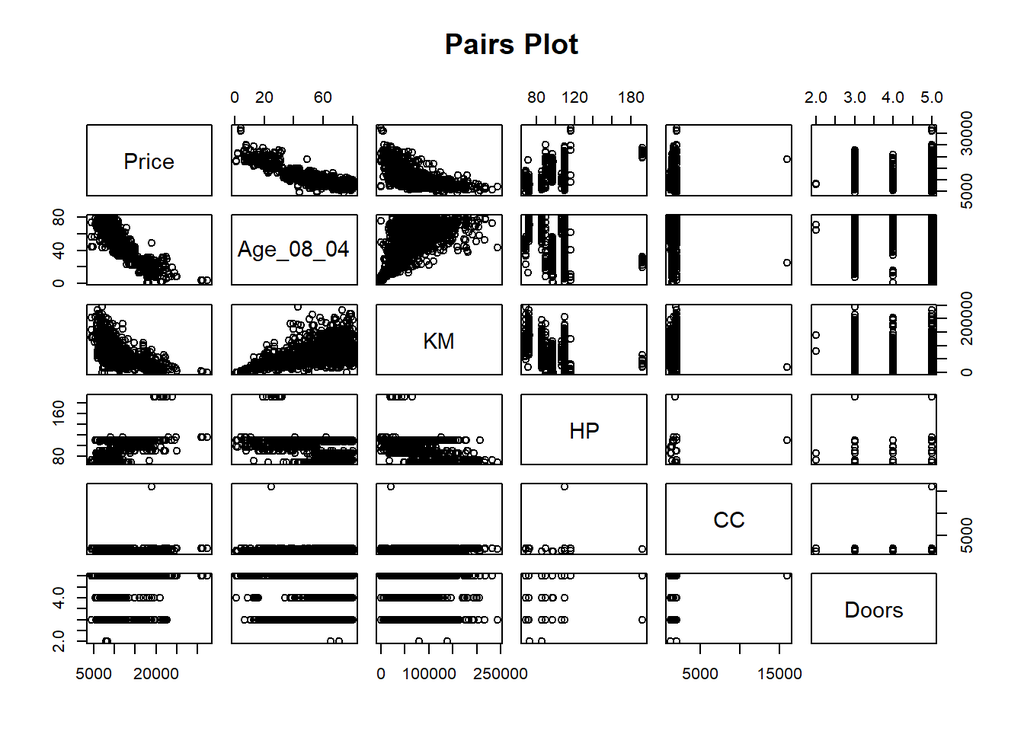

```r
numerical_vars <- c("Price", "Age_08_04", "KM", "HP", "CC", "Doors")


pairs(data[numerical_vars], main="Pairs Plot")
```

Here, one of the most remarkable relation is between price and age. There is a strong negative relationship; older cars tend to have lower prices. And also there is a positive relationship between horsepower and price, meaning that cars with more power tend to be priced higher. Also the relationship between cylinder volume and price is less clear. There might be some correlation, but hard to make a comment from this plot.

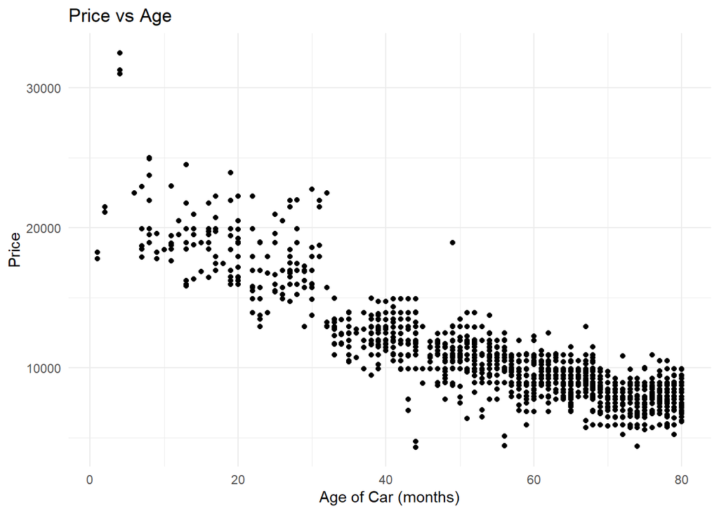

```r
ggplot(data, aes(x = Age_08_04, y = Price)) +
  geom_point() +
  ggtitle("Price vs Age") +
  xlab("Age of Car (months)") +
  ylab("Price") +
  theme_minimal()
```

As also mentioned in the comment before, this plot shows a negative correlation. As the car’s age increases, the price tends to decrease. This is logical since older cars generally have lower market values.

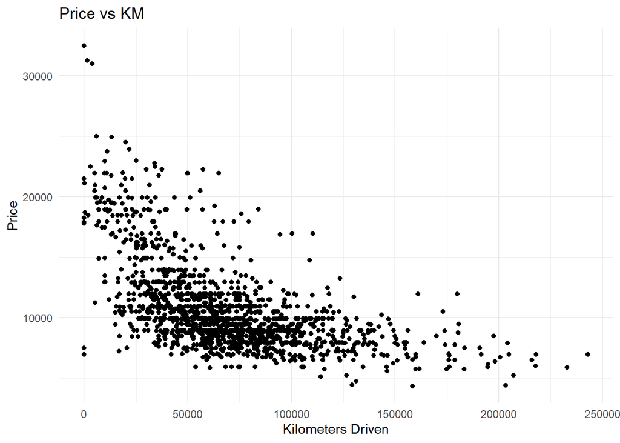

```r
ggplot(data, aes(x = KM, y = Price)) +
  geom_point() +
  ggtitle("Price vs KM") +
  xlab("Kilometers Driven") +
  ylab("Price") +
  theme_minimal()
```

Again, there is a negative correlation. Cars that have been driven more kilometers tend to be priced lower. Looks like a normal result as higher usage generally decreases a car’s value.

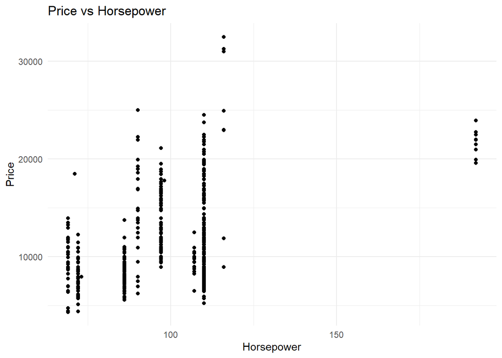

```r
ggplot(data, aes(x = HP, y = Price)) +
  geom_point() +
  ggtitle("Price vs Horsepower") +
  xlab("Horsepower") +
  ylab("Price") +
  theme_minimal()
```

This plot shows that cars with higher horsepower tend to have a higher market value, but it also suggests that horsepower alone isn’t the only factor affecting price, as we see price variation even within similar horsepower ranges.

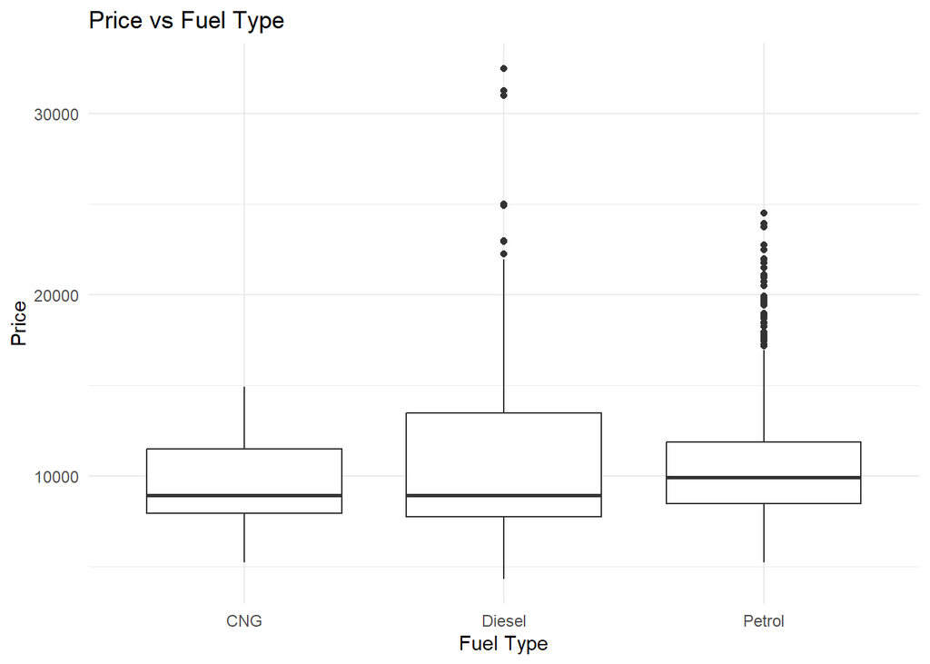

```r
ggplot(data, aes(x = Fuel_Type, y = Price)) +
  geom_boxplot() +
  ggtitle("Price vs Fuel Type") +
  xlab("Fuel Type") +
  ylab("Price") +
  theme_minimal()
```

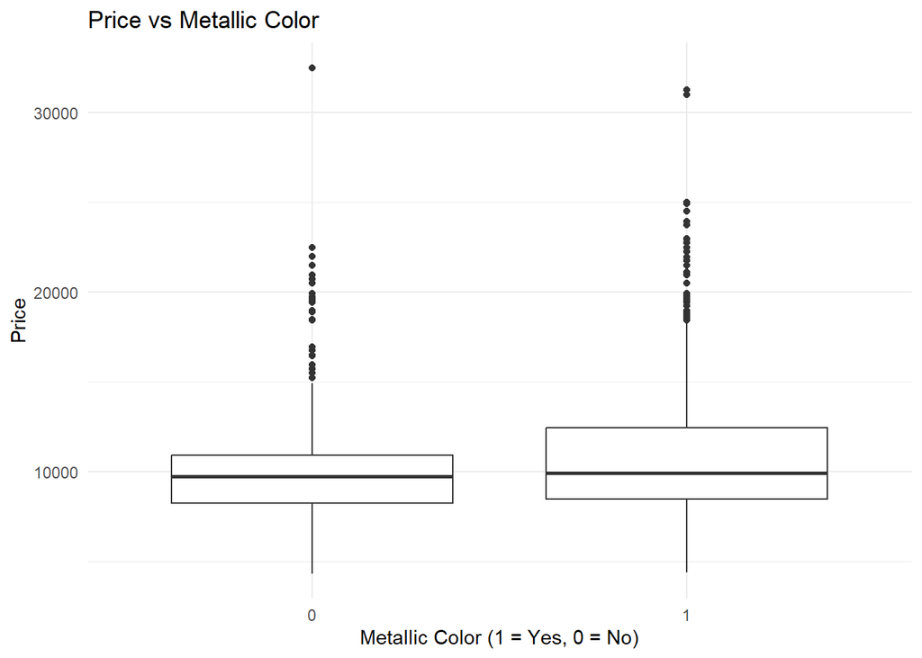

```r
ggplot(data, aes(x = as.factor(Met_Color), y = Price)) +
  geom_boxplot() +
  ggtitle("Price vs Metallic Color") +
  xlab("Metallic Color (1 = Yes, 0 = No)") +
  ylab("Price") +
  theme_minimal()
```

Cars with metallic colors tend to have slightly higher prices compared to cars without it. However, the effect is not very large, so its suggesting that color is not a major factor in determining price.

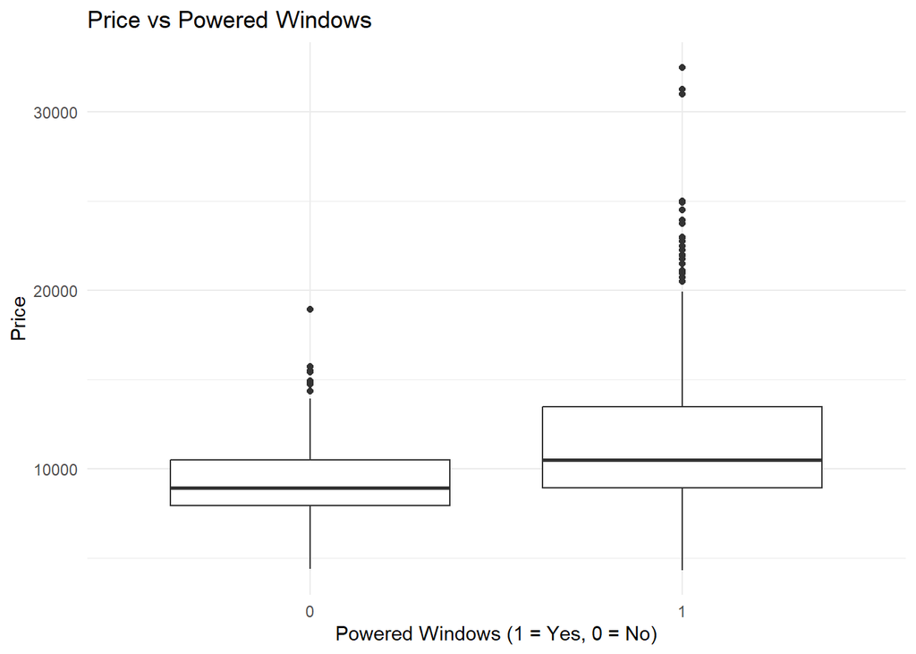

```r
ggplot(data, aes(x = as.factor(Powered_Windows), y = Price)) +
  geom_boxplot() +
  ggtitle("Price vs Powered Windows") +
  xlab("Powered Windows (1 = Yes, 0 = No)") +
  ylab("Price") +
  theme_minimal()
```

Similarly, powered windows tend to have higher prices but still the effect is not very large. This slightly change can be explained by powered windows are often associated with more luxury or newer models.

# 2 2- Propose a multiple regression model.

```r
model <- lm(Price ~ Age_08_04 + KM + HP + Met_Color + Powered_Windows + Power_Steering + Fuel_Type, data = data)

summary(model)
```

```
Call:
lm(formula = Price ~ Age_08_04 + KM + HP + Met_Color + Powered_Windows +
    Power_Steering + Fuel_Type, data = data)

Residuals:
    Min      1Q  Median      3Q     Max
-7122.5  -873.8   -42.0   816.4 10244.0

Coefficients:
                  Estimate Std. Error t value Pr(>|t|)
(Intercept)      1.348e+04  5.949e+02  22.660  < 2e-16 ***
Age_08_04       -1.352e+02  2.766e+00 -48.867  < 2e-16 ***
KM              -2.031e-02  1.448e-03 -14.026  < 2e-16 ***
HP               5.291e+01  3.225e+00  16.406  < 2e-16 ***
Met_Color       -4.077e+01  8.394e+01  -0.486    0.627
Powered_Windows  6.449e+02  8.477e+01   7.609 5.00e-14 ***
Power_Steering  -1.805e+02  2.654e+02  -0.680    0.497
Fuel_TypeDiesel  2.714e+03  3.886e+02   6.983 4.41e-12 ***
Fuel_TypePetrol  4.330e+02  3.677e+02   1.178    0.239
---
Signif. codes:  0 '***' 0.001 '**' 0.01 '*' 0.05 '.' 0.1 ' ' 1

Residual standard error: 1466 on 1427 degrees of freedom
Multiple R-squared:  0.8376,    Adjusted R-squared:  0.8367
F-statistic: 919.8 on 8 and 1427 DF,  p-value: < 2.2e-16
```

# 3 3- How good does your model fit to the data?

Here in this model we get R-squared value of 0.8376, which shows that 83.76% of the variability in the car prices is explained by the model. So this is a good fit. Shows the predictors chosen capture much of the variance in the price.

Also Adjusted R-squared is 0.8367, which is very close to the R-squared. This means that the model doesn’t suffer much from over fitting due to unnecessary variables. And the F-statistic of 919.8 with a p-value of < 2.2e-16 shows that the overall model is statistically accurate, and at least one of the predictors has a important relationship with the response variable. The residual standart error is 1466 suggests the typical error or deviation is around 1466. Given that car prices in the data set can range widely, this might be acceptable, but of course a lower value would be better.

Analyzing the results for coefficients, Age, KM, HP, Powered_Windows, and Fuel_TypeDiesel are outstanding predictors, as indicated by their small p-values. On the other hand Met_Color, Power_Steering, and Fuel_TypePetrol do not appear to have a important relationship with prices.

To also check the diagnostic plots:

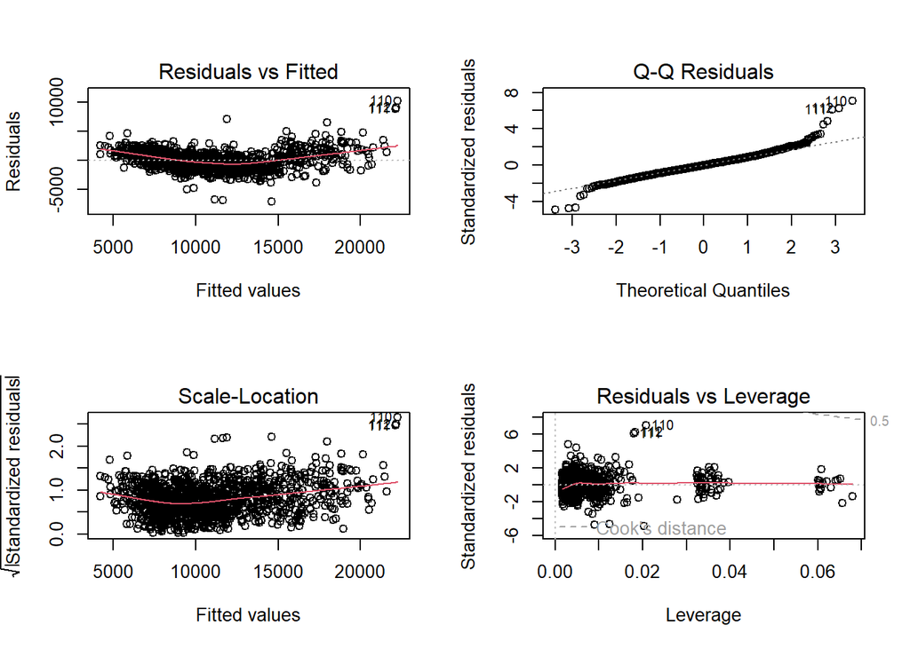

```r
linear_model <- lm(Price ~ Age_08_04 + KM + HP + Met_Color + Powered_Windows + Power_Steering + Fuel_Type, data = data)

par(mfrow = c(2, 2))
plot(linear_model)
```

So in these graphs, Residuals vs Fitted plot has a clear pattern, especially with a slight curve, signaling possible non-linearity. In the Q-Q Residuals, points deviate from the diagonal line at the tails. This shows the residuals are not perfectly normally distributed. This may also suggest potential issues with the assumption of normality. The scale-location plot has a curvature in the residuals and it looks like we need to make further adjustments to improve our model. It may not capture all patterns in the data.

To update the model, based on the coefficient p-values, we might consider removing the insignificant variables to simplify and improve the model.

```r
model_updated <- lm(Price ~ Age_08_04 + KM + HP + Powered_Windows + Fuel_Type, data = data)
```

# 4 4- How much does the expected price change if a car’s age increases by one year while everything else are fixed?

```r
age_coef <- coef(model_updated)["Age_08_04"]
price_change <- age_coef * 12
print(price_change)
```

```
Age_08_04
-1620.278
```

# 5 5- Predict the expected price and give its 80% confidence interval for a typical car with all features set to their sample means for the numerical predictors and to the most frequent categories for the categorical predictors.

```r
typical_car <- data.frame(
  Age_08_04 = mean(data$Age_08_04),
  KM = mean(data$KM),
  HP = mean(data$HP),
  Met_Color = as.numeric(names(sort(table(data$Met_Color), decreasing = TRUE))[1]),
  Powered_Windows =  as.numeric(names(sort(table(data$Powered_Windows), decreasing = TRUE))[1]),
  Power_Steering = as.numeric(names(sort(table(data$Power_Steering), decreasing = TRUE))[1]),
  Fuel_Type = as.factor(names(sort(table(data$Fuel_Type), decreasing = TRUE))[1])
)


predicted_price <- predict(model_updated, typical_car, interval = "confidence", level = 0.80)
print(predicted_price)
```

```
       fit      lwr      upr
1 10768.15 10695.96 10840.35
```